# Childers_Lab3

Heather Childers

1/31/2024

## Lab 3: Predicting the age of abalone

Abalones are marine snails. Their flesh is widely considered to be a desirable food, and is consumed raw or cooked by a variety of cultures. The age of abalone is determined by cutting the shell through the cone, staining it, and counting the number of rings through a microscope – a boring and time-consuming task. Other measurements, which are easier to obtain, are used to predict the age.

The data set provided includes variables related to the sex, physical dimensions of the shell, and various weight measurements, along with the number of rings in the shell. Number of rings is the stand-in here for age.

### Data Exploration

Pull the abalone data from Github and take a look at it.

```r
abdat<- read_csv(file = "https://raw.githubusercontent.com/MaRo406/eds-232-machine-learning/main/data/abalone-data.csv")
glimpse(abdat)
```

```
## Rows: 4,177
## Columns: 10
## $ ...1           <dbl> 1, 2, 3, 4, 5, 6, 7, 8, 9, 10, 11, 12, 13, 14, 15, 16, …
## $ Sex            <chr> "M", "M", "F", "M", "I", "I", "F", "F", "M", "F", "F", …
## $ Length         <dbl> 0.455, 0.350, 0.530, 0.440, 0.330, 0.425, 0.530, 0.545,…
## $ Diameter       <dbl> 0.365, 0.265, 0.420, 0.365, 0.255, 0.300, 0.415, 0.425,…
## $ Height         <dbl> 0.095, 0.090, 0.135, 0.125, 0.080, 0.095, 0.150, 0.125,…
## $ Whole_weight   <dbl> 0.5140, 0.2255, 0.6770, 0.5160, 0.2050, 0.3515, 0.7775,…
## $ Shucked_weight <dbl> 0.2245, 0.0995, 0.2565, 0.2155, 0.0895, 0.1410, 0.2370,…
## $ Viscera_weight <dbl> 0.1010, 0.0485, 0.1415, 0.1140, 0.0395, 0.0775, 0.1415,…
## $ Shell_weight   <dbl> 0.150, 0.070, 0.210, 0.155, 0.055, 0.120, 0.330, 0.260,…
## $ Rings          <dbl> 15, 7, 9, 10, 7, 8, 20, 16, 9, 19, 14, 10, 11, 10, 10, …
```

### Data Splitting

- *Question 1*. Split the data into training and test sets. Use a 70/30 training/test split.

We’ll follow our text book’s lead and use the caret package in our approach to this task. We will use the glmnet package in order to perform ridge regression and the lasso. The main function in this package is glmnet(), which can be used to fit ridge regression models, lasso models, and more. In particular, we must pass in an x matrix of predictors as well as a y outcome vector , and we do not use the y∼x syntax.

```r
abalone <- initial_split(abdat, prop = .7)

train <- training(abalone)
test <- testing(abalone)
```

### Fit a ridge regression model

- *Question 2*. Use the model.matrix() function to create a predictor matrix, x, and assign the Rings variable to an outcome vector, y.

```r
X <- model.matrix(Rings ~ ., data = train)[,-1]

# transform y with log() transformation
Y <- log(train$Rings)
```

- *Question 3*. Fit a ridge model (controlled by the alpha parameter) using the glmnet() function. Make a plot showing how the estimated coefficients change with lambda. (Hint: You can call plot() directly on the glmnet() objects).

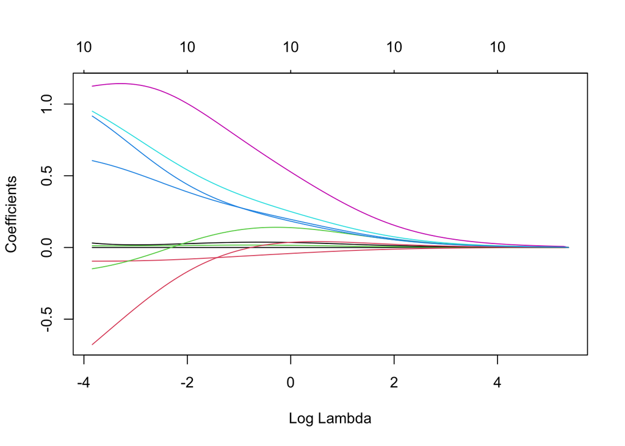

```r
ridge <- glmnet(
  x = X, #model matrix
  y = Y, #log transformed data
  alpha = 0 #Specifies ridge or Lasso model, 0 = ridge, 1 = model
)

plot(ridge, xvar = "lambda")
```

### Using *k*-fold cross validation resampling and tuning our models

In lecture we learned about two methods of estimating our model’s generalization error by resampling, cross validation and bootstrapping. We’ll use the *k*-fold cross validation method in this lab. Recall that lambda is a tuning parameter that helps keep our model from over-fitting to the training data. Tuning is the process of finding the optima value of lamba.

- *Question 4*. This time fit a ridge regression model and a lasso model, both with using cross validation. The glmnet package kindly provides a cv.glmnet() function to do this (similar to the glmnet() function that we just used). Use the alpha argument to control which type of model you are running. Plot the results.

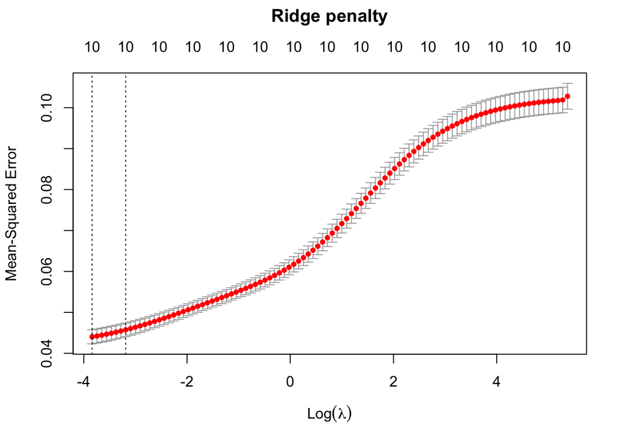

```r
# Apply Cross Validation for a ridge regression model to the Abalone data.
ridge_cv <- cv.glmnet(
  x = X,
  y = Y,
  alpha = 0
)
#Plot the Results
plot(ridge_cv, main = "Ridge penalty\n\n")
```

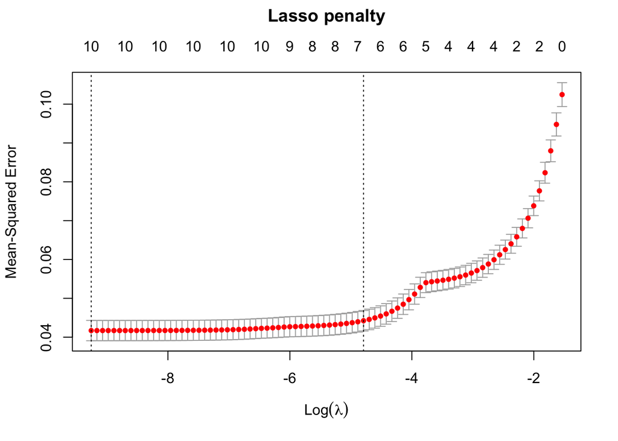

```r
# Apply CV lasso regression to Ames data
#defualts to ten folds
lasso_cv <- cv.glmnet(
  x = X,
  y = Y,
  alpha = 1
)
#Plot the results
plot(lasso_cv, main = "Lasso penalty\n\n")
```

- *Question 5*. Interpret the graphs. What is being displayed on the axes here? How does the performance of the models change with the value of lambda?
  - Both of the above graphs are showing the change in Mean Squared Error as the tuning parameter, lambda, increases. For both models you can see that the mean squared error increases as the log of lambda increases. This makes sense because as lamba increases, the penalty from larger coefficients increases. There are a few interesting things to point out about these graphs:
    1. The values of lambda for the lasso regression are much smaller than they are for the ridge regression for a relatively similar mean squared error value
    2. This graphs allow us to see that the mean squared error value will increase almost exponentially for the lasso regression, and the ridge regression shows that the mean squared error will eventually plateau.
- *Question 6*. Inspect the ridge model object you created with cv.glmnet(). The $cvm column shows the MSEs for each CV fold. What is the minimum MSE? What is the value of lambda associated with this MSE minimum?

```r
#Ridge model stats
# minimum MSE
min_ridge <- min(ridge_cv$cvm)
print(paste("The minimum mean squared error for the ridge regression is",min_ridge))
```

```
## [1] "The minimum mean squared error for the ridge regression is 0.0440370934500391"
```

```r
# lambda for this min MSE
lam_ridge <- ridge_cv$lambda.min
print(paste("The lambda value for the minimum mean squared error for the ridge regression is",lam_ridge))
```

```
## [1] "The lambda value for the minimum mean squared error for the ridge regression is 0.0215204061849633"
```

- *Question 7*. Do the same for the lasso model. What is the minimum MSE? What is the value of lambda associated with this MSE minimum?

```r
#Lasso model stats
# minimum MSE
min_lasso <- min(lasso_cv$cvm)
print(paste("The minimum mean squared error for the lasso regression is",min_lasso))
```

```
## [1] "The minimum mean squared error for the lasso regression is 0.0416989286335899"
```

```r
# lambda for this min MSE
lam_lasso <- lasso_cv$lambda.min
print(paste("The lambda value for the minimum mean squared error for the lasso regression is",lam_lasso))
```

```
## [1] "The lambda value for the minimum mean squared error for the lasso regression is 9.53487734190192e-05"
```

Data scientists often use the “one-standard-error” rule when tuning lambda to select the best model. This rule tells us to pick the most parsimonious model (fewest number of predictors) while still remaining within one standard error of the overall minimum cross validation error. The cv.glmnet() model object has a column that automatically finds the value of lambda associated with the model that produces an MSE that is one standard error from the MSE minimum ($lambda.1se).

- *Question 8.* Find the number of predictors associated with this model (hint: the $nzero is the # of predictors column).

```r
#For the ridge model:
# No. of coef | 1-SE MSE
ridge_cv$nzero[ridge_cv$lambda == ridge_cv$lambda.min]
```

```
## s99
##  10
```

```r
#For the lasso model:
# No. of coef | 1-SE MSE
lasso_cv$nzero[lasso_cv$lambda == lasso_cv$lambda.min]
```

```
## s83
##  10
```

- *Question 9*. Which regularized regression worked better for this task, ridge or lasso? Explain your answer.